# Optimal Treatment Analysis

## Outcome Variable

**Outcome Variable:** whz

## Predictor Variables

**Intervention Variable:** predfeed36

**Adjustment Set:**

- arm
- sex
- month
- brthmon
- W_mage
- meducyrs
- feducyrs
- hhwealth_quart
- hfoodsec
- W_mhtcm
- W_mwtkg
- W_mbmi
- vagbrth
- W_gagebrth
- W_birthwt
- W_birthlen
- W_nrooms
- W_nchldlt5
- W_parity
- impfloor
- impsan
- safeh20
- delta_W_mage
- delta_meducyrs
- delta_feducyrs
- delta_hhwealth_quart
- delta_hfoodsec
- delta_W_mhtcm
- delta_W_mwtkg
- delta_W_mbmi
- delta_vagbrth
- delta_W_gagebrth
- delta_W_birthwt
- delta_W_birthlen
- delta_W_nrooms
- delta_W_nchldlt5
- delta_W_parity
- delta_impfloor
- delta_impsan
- delta_safeh20

## Stratifying Variables

The analysis was stratified on these variable(s):

- agecat
- studyid
- country

## Data Summary

| agecat | studyid | country | predfeed36 | n_cell | n |
| --- | --- | --- | --- | --- | --- |
| Birth | ki0047075b-MAL-ED | BANGLADESH | 1 | 69 | 208 |
| Birth | ki0047075b-MAL-ED | BANGLADESH | 0 | 139 | 208 |
| Birth | ki0047075b-MAL-ED | BRAZIL | 1 | 7 | 62 |
| Birth | ki0047075b-MAL-ED | BRAZIL | 0 | 55 | 62 |
| Birth | ki0047075b-MAL-ED | INDIA | 1 | 4 | 40 |
| Birth | ki0047075b-MAL-ED | INDIA | 0 | 36 | 40 |
| Birth | ki0047075b-MAL-ED | NEPAL | 1 | 1 | 25 |
| Birth | ki0047075b-MAL-ED | NEPAL | 0 | 24 | 25 |
| Birth | ki0047075b-MAL-ED | PERU | 1 | 57 | 218 |
| Birth | ki0047075b-MAL-ED | PERU | 0 | 161 | 218 |
| Birth | ki0047075b-MAL-ED | SOUTH AFRICA | 1 | 2 | 104 |
| Birth | ki0047075b-MAL-ED | SOUTH AFRICA | 0 | 102 | 104 |
| Birth | ki0047075b-MAL-ED | TANZANIA, UNITED REPUBLIC OF | 1 | 0 | 111 |
| Birth | ki0047075b-MAL-ED | TANZANIA, UNITED REPUBLIC OF | 0 | 111 | 111 |
| Birth | ki1000109-EE | PAKISTAN | 1 | 2 | 6 |
| Birth | ki1000109-EE | PAKISTAN | 0 | 4 | 6 |
| Birth | ki1113344-GMS-Nepal | NEPAL | 1 | 396 | 491 |
| Birth | ki1113344-GMS-Nepal | NEPAL | 0 | 95 | 491 |
| Birth | kiGH5241-JiVitA-3 | BANGLADESH | 1 | 8205 | 10491 |
| Birth | kiGH5241-JiVitA-3 | BANGLADESH | 0 | 2286 | 10491 |
| Birth | kiGH5241-JiVitA-4 | BANGLADESH | 1 | 1714 | 2128 |
| Birth | kiGH5241-JiVitA-4 | BANGLADESH | 0 | 414 | 2128 |
| 6 months | ki0047075b-MAL-ED | BANGLADESH | 1 | 81 | 240 |
| 6 months | ki0047075b-MAL-ED | BANGLADESH | 0 | 159 | 240 |
| 6 months | ki0047075b-MAL-ED | BRAZIL | 1 | 25 | 209 |
| 6 months | ki0047075b-MAL-ED | BRAZIL | 0 | 184 | 209 |
| 6 months | ki0047075b-MAL-ED | INDIA | 1 | 17 | 233 |
| 6 months | ki0047075b-MAL-ED | INDIA | 0 | 216 | 233 |
| 6 months | ki0047075b-MAL-ED | NEPAL | 1 | 8 | 235 |
| 6 months | ki0047075b-MAL-ED | NEPAL | 0 | 227 | 235 |
| 6 months | ki0047075b-MAL-ED | PERU | 1 | 72 | 272 |
| 6 months | ki0047075b-MAL-ED | PERU | 0 | 200 | 272 |
| 6 months | ki0047075b-MAL-ED | SOUTH AFRICA | 1 | 3 | 250 |
| 6 months | ki0047075b-MAL-ED | SOUTH AFRICA | 0 | 247 | 250 |
| 6 months | ki0047075b-MAL-ED | TANZANIA, UNITED REPUBLIC OF | 1 | 5 | 243 |
| 6 months | ki0047075b-MAL-ED | TANZANIA, UNITED REPUBLIC OF | 0 | 238 | 243 |
| 6 months | ki1000109-EE | PAKISTAN | 1 | 4 | 9 |
| 6 months | ki1000109-EE | PAKISTAN | 0 | 5 | 9 |
| 6 months | ki1000304b-SAS-FoodSuppl | INDIA | 1 | 0 | 168 |
| 6 months | ki1000304b-SAS-FoodSuppl | INDIA | 0 | 168 | 168 |
| 6 months | ki1113344-GMS-Nepal | NEPAL | 1 | 422 | 527 |
| 6 months | ki1113344-GMS-Nepal | NEPAL | 0 | 105 | 527 |
| 6 months | ki1148112-LCNI-5 | MALAWI | 1 | 47 | 272 |
| 6 months | ki1148112-LCNI-5 | MALAWI | 0 | 225 | 272 |
| 6 months | kiGH5241-JiVitA-3 | BANGLADESH | 1 | 6559 | 8516 |
| 6 months | kiGH5241-JiVitA-3 | BANGLADESH | 0 | 1957 | 8516 |
| 6 months | kiGH5241-JiVitA-4 | BANGLADESH | 1 | 3252 | 4188 |
| 6 months | kiGH5241-JiVitA-4 | BANGLADESH | 0 | 936 | 4188 |
| 24 months | ki0047075b-MAL-ED | BANGLADESH | 1 | 69 | 212 |
| 24 months | ki0047075b-MAL-ED | BANGLADESH | 0 | 143 | 212 |
| 24 months | ki0047075b-MAL-ED | BRAZIL | 1 | 20 | 169 |
| 24 months | ki0047075b-MAL-ED | BRAZIL | 0 | 149 | 169 |
| 24 months | ki0047075b-MAL-ED | INDIA | 1 | 17 | 224 |
| 24 months | ki0047075b-MAL-ED | INDIA | 0 | 207 | 224 |
| 24 months | ki0047075b-MAL-ED | NEPAL | 1 | 8 | 227 |
| 24 months | ki0047075b-MAL-ED | NEPAL | 0 | 219 | 227 |
| 24 months | ki0047075b-MAL-ED | PERU | 1 | 53 | 201 |
| 24 months | ki0047075b-MAL-ED | PERU | 0 | 148 | 201 |
| 24 months | ki0047075b-MAL-ED | SOUTH AFRICA | 1 | 3 | 235 |
| 24 months | ki0047075b-MAL-ED | SOUTH AFRICA | 0 | 232 | 235 |
| 24 months | ki0047075b-MAL-ED | TANZANIA, UNITED REPUBLIC OF | 1 | 4 | 213 |
| 24 months | ki0047075b-MAL-ED | TANZANIA, UNITED REPUBLIC OF | 0 | 209 | 213 |
| 24 months | ki1000109-EE | PAKISTAN | 1 | 0 | 3 |
| 24 months | ki1000109-EE | PAKISTAN | 0 | 3 | 3 |
| 24 months | ki1113344-GMS-Nepal | NEPAL | 1 | 362 | 445 |
| 24 months | ki1113344-GMS-Nepal | NEPAL | 0 | 83 | 445 |
| 24 months | ki1148112-LCNI-5 | MALAWI | 1 | 34 | 184 |
| 24 months | ki1148112-LCNI-5 | MALAWI | 0 | 150 | 184 |
| 24 months | kiGH5241-JiVitA-3 | BANGLADESH | 1 | 3297 | 4283 |
| 24 months | kiGH5241-JiVitA-3 | BANGLADESH | 0 | 986 | 4283 |
| 24 months | kiGH5241-JiVitA-4 | BANGLADESH | 1 | 3144 | 4035 |
| 24 months | kiGH5241-JiVitA-4 | BANGLADESH | 0 | 891 | 4035 |

The following strata were considered:

- agecat: 24 months, studyid: ki0047075b-MAL-ED, country: BANGLADESH
- agecat: 24 months, studyid: ki0047075b-MAL-ED, country: BRAZIL
- agecat: 24 months, studyid: ki0047075b-MAL-ED, country: INDIA
- agecat: 24 months, studyid: ki0047075b-MAL-ED, country: NEPAL
- agecat: 24 months, studyid: ki0047075b-MAL-ED, country: PERU
- agecat: 24 months, studyid: ki0047075b-MAL-ED, country: SOUTH AFRICA
- agecat: 24 months, studyid: ki0047075b-MAL-ED, country: TANZANIA, UNITED REPUBLIC OF
- agecat: 24 months, studyid: ki1000109-EE, country: PAKISTAN
- agecat: 24 months, studyid: ki1113344-GMS-Nepal, country: NEPAL
- agecat: 24 months, studyid: ki1148112-LCNI-5, country: MALAWI
- agecat: 24 months, studyid: kiGH5241-JiVitA-3, country: BANGLADESH
- agecat: 24 months, studyid: kiGH5241-JiVitA-4, country: BANGLADESH
- agecat: 6 months, studyid: ki0047075b-MAL-ED, country: BANGLADESH
- agecat: 6 months, studyid: ki0047075b-MAL-ED, country: BRAZIL
- agecat: 6 months, studyid: ki0047075b-MAL-ED, country: INDIA
- agecat: 6 months, studyid: ki0047075b-MAL-ED, country: NEPAL
- agecat: 6 months, studyid: ki0047075b-MAL-ED, country: PERU
- agecat: 6 months, studyid: ki0047075b-MAL-ED, country: SOUTH AFRICA
- agecat: 6 months, studyid: ki0047075b-MAL-ED, country: TANZANIA, UNITED REPUBLIC OF
- agecat: 6 months, studyid: ki1000109-EE, country: PAKISTAN
- agecat: 6 months, studyid: ki1000304b-SAS-FoodSuppl, country: INDIA
- agecat: 6 months, studyid: ki1113344-GMS-Nepal, country: NEPAL
- agecat: 6 months, studyid: ki1148112-LCNI-5, country: MALAWI
- agecat: 6 months, studyid: kiGH5241-JiVitA-3, country: BANGLADESH
- agecat: 6 months, studyid: kiGH5241-JiVitA-4, country: BANGLADESH
- agecat: Birth, studyid: ki0047075b-MAL-ED, country: BANGLADESH
- agecat: Birth, studyid: ki0047075b-MAL-ED, country: BRAZIL
- agecat: Birth, studyid: ki0047075b-MAL-ED, country: INDIA
- agecat: Birth, studyid: ki0047075b-MAL-ED, country: NEPAL
- agecat: Birth, studyid: ki0047075b-MAL-ED, country: PERU
- agecat: Birth, studyid: ki0047075b-MAL-ED, country: SOUTH AFRICA
- agecat: Birth, studyid: ki0047075b-MAL-ED, country: TANZANIA, UNITED REPUBLIC OF
- agecat: Birth, studyid: ki1000109-EE, country: PAKISTAN
- agecat: Birth, studyid: ki1113344-GMS-Nepal, country: NEPAL
- agecat: Birth, studyid: kiGH5241-JiVitA-3, country: BANGLADESH
- agecat: Birth, studyid: kiGH5241-JiVitA-4, country: BANGLADESH

### Dropped Strata

Some strata were dropped due to rare outcomes:

- agecat: Birth, studyid: ki0047075b-MAL-ED, country: INDIA
- agecat: Birth, studyid: ki0047075b-MAL-ED, country: NEPAL
- agecat: Birth, studyid: ki0047075b-MAL-ED, country: SOUTH AFRICA
- agecat: Birth, studyid: ki0047075b-MAL-ED, country: TANZANIA, UNITED REPUBLIC OF
- agecat: Birth, studyid: ki1000109-EE, country: PAKISTAN
- agecat: 6 months, studyid: ki0047075b-MAL-ED, country: SOUTH AFRICA
- agecat: 6 months, studyid: ki1000109-EE, country: PAKISTAN
- agecat: 6 months, studyid: ki1000304b-SAS-FoodSuppl, country: INDIA
- agecat: 24 months, studyid: ki0047075b-MAL-ED, country: SOUTH AFRICA
- agecat: 24 months, studyid: ki0047075b-MAL-ED, country: TANZANIA, UNITED REPUBLIC OF
- agecat: 24 months, studyid: ki1000109-EE, country: PAKISTAN

## Methods Detail

We’re interested in the causal parameters $E[Y_a]$ for all values of $a \in \mathcal{A}$. These parameters represent the mean outcome if, possibly contrary to fact, we intervened to set all units to have $A=a$. Under the randomization and positivity assumptions, these are identified by the statistical parameters $\psi_a=E_W[E_{Y|A,W}(Y|A=a,W)]$. In addition, we’re interested in the mean of $Y$, $E[Y]$ under no intervention (the observed mean). We will estimate these parameters by using SuperLearner to fit the relevant likelihood factors – $E_{Y|A,W}(Y|A=a,W)$ and $p(A=a|W)$, and then updating our likelihood fit using a joint TMLE.

For unadjusted analyses ($W=\{\}$), initial likelihoods were estimated using Lrnr_glm to estimate the simple $E(Y|A)$ and Lrnr_mean to estimate $p(A)$. For adjusted analyses, a small library containing Lrnr_glmnet, Lrnr_xgboost, and Lrnr_mean was used.

Having estimated these parameters, we will then use the delta method to estimate relative risks and attributable risks relative to a prespecified baseline level of $A$.

# Results Detail

## Results Plots

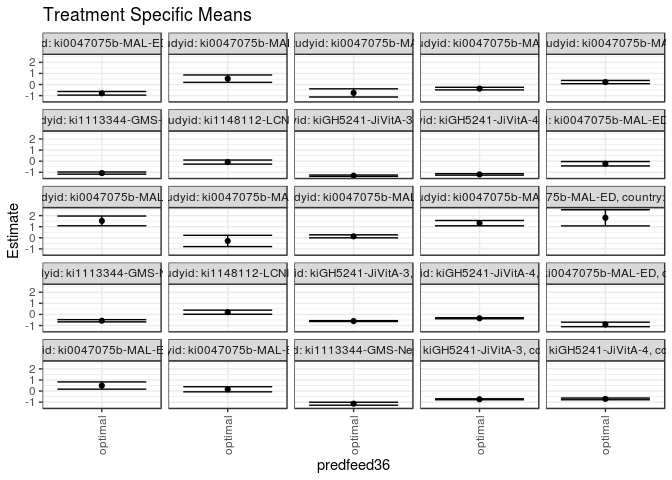

## Results Table

### Parameter: TSM

| agecat | studyid | country | intervention_level | baseline_level | estimate | ci_lower | ci_upper |
| --- | --- | --- | --- | --- | --- | --- | --- |
| Birth | ki0047075b-MAL-ED | BANGLADESH | optimal | observed | -0.9007063 | -1.1056433 | -0.6957693 |
| Birth | ki0047075b-MAL-ED | BRAZIL | optimal | observed | 0.4973991 | 0.1706222 | 0.8241760 |
| Birth | ki0047075b-MAL-ED | PERU | optimal | observed | 0.1602392 | -0.0673762 | 0.3878546 |
| Birth | ki1113344-GMS-Nepal | NEPAL | optimal | observed | -1.1381354 | -1.2704295 | -1.0058413 |
| Birth | kiGH5241-JiVitA-3 | BANGLADESH | optimal | observed | -0.7380982 | -0.7830328 | -0.6931635 |
| Birth | kiGH5241-JiVitA-4 | BANGLADESH | optimal | observed | -0.7055717 | -0.7812375 | -0.6299060 |
| 6 months | ki0047075b-MAL-ED | BANGLADESH | optimal | observed | -0.2309277 | -0.4286370 | -0.0332184 |
| 6 months | ki0047075b-MAL-ED | BRAZIL | optimal | observed | 1.5228063 | 1.0846060 | 1.9610066 |
| 6 months | ki0047075b-MAL-ED | INDIA | optimal | observed | -0.2827734 | -0.7910632 | 0.2255164 |
| 6 months | ki0047075b-MAL-ED | NEPAL | optimal | observed | 0.1299320 | -0.0040873 | 0.2639513 |
| 6 months | ki0047075b-MAL-ED | PERU | optimal | observed | 1.3207296 | 1.0811918 | 1.5602674 |
| 6 months | ki0047075b-MAL-ED | TANZANIA, UNITED REPUBLIC OF | optimal | observed | 1.8003565 | 1.0718862 | 2.5288267 |
| 6 months | ki1113344-GMS-Nepal | NEPAL | optimal | observed | -0.5686245 | -0.6692679 | -0.4679811 |
| 6 months | ki1148112-LCNI-5 | MALAWI | optimal | observed | 0.2009905 | 0.0150325 | 0.3869485 |
| 6 months | kiGH5241-JiVitA-3 | BANGLADESH | optimal | observed | -0.5983390 | -0.6349299 | -0.5617480 |
| 6 months | kiGH5241-JiVitA-4 | BANGLADESH | optimal | observed | -0.3440292 | -0.3895758 | -0.2984826 |
| 24 months | ki0047075b-MAL-ED | BANGLADESH | optimal | observed | -0.7891364 | -0.9516458 | -0.6266271 |
| 24 months | ki0047075b-MAL-ED | BRAZIL | optimal | observed | 0.5287360 | 0.1966840 | 0.8607880 |
| 24 months | ki0047075b-MAL-ED | INDIA | optimal | observed | -0.7546321 | -1.1226077 | -0.3866565 |
| 24 months | ki0047075b-MAL-ED | NEPAL | optimal | observed | -0.3657892 | -0.4821742 | -0.2494043 |
| 24 months | ki0047075b-MAL-ED | PERU | optimal | observed | 0.2209474 | 0.0746045 | 0.3672904 |
| 24 months | ki1113344-GMS-Nepal | NEPAL | optimal | observed | -1.0698143 | -1.1678121 | -0.9718164 |
| 24 months | ki1148112-LCNI-5 | MALAWI | optimal | observed | -0.0813556 | -0.2663846 | 0.1036733 |
| 24 months | kiGH5241-JiVitA-3 | BANGLADESH | optimal | observed | -1.3092891 | -1.3717024 | -1.2468758 |
| 24 months | kiGH5241-JiVitA-4 | BANGLADESH | optimal | observed | -1.1955006 | -1.2620012 | -1.1289999 |

### Parameter: E(Y)

| agecat | studyid | country | intervention_level | baseline_level | estimate | ci_lower | ci_upper |
| --- | --- | --- | --- | --- | --- | --- | --- |
| Birth | ki0047075b-MAL-ED | BANGLADESH | observed | observed | -0.9474038 | -1.0929246 | -0.8018831 |
| Birth | ki0047075b-MAL-ED | BRAZIL | observed | observed | 0.4029032 | 0.0896793 | 0.7161272 |
| Birth | ki0047075b-MAL-ED | PERU | observed | observed | -0.0458257 | -0.1696487 | 0.0779973 |
| Birth | ki1113344-GMS-Nepal | NEPAL | observed | observed | -1.1085743 | -1.2077878 | -1.0093609 |
| Birth | kiGH5241-JiVitA-3 | BANGLADESH | observed | observed | -0.7602278 | -0.7829387 | -0.7375169 |
| Birth | kiGH5241-JiVitA-4 | BANGLADESH | observed | observed | -0.7018985 | -0.7560164 | -0.6477806 |
| 6 months | ki0047075b-MAL-ED | BANGLADESH | observed | observed | -0.1361806 | -0.2655204 | -0.0068407 |
| 6 months | ki0047075b-MAL-ED | BRAZIL | observed | observed | 0.9717225 | 0.8073791 | 1.1360658 |
| 6 months | ki0047075b-MAL-ED | INDIA | observed | observed | -0.7164664 | -0.8440835 | -0.5888492 |
| 6 months | ki0047075b-MAL-ED | NEPAL | observed | observed | 0.1146454 | -0.0170405 | 0.2463313 |
| 6 months | ki0047075b-MAL-ED | PERU | observed | observed | 1.0551961 | 0.9331945 | 1.1771976 |
| 6 months | ki0047075b-MAL-ED | TANZANIA, UNITED REPUBLIC OF | observed | observed | 0.5508093 | 0.4191033 | 0.6825154 |
| 6 months | ki1113344-GMS-Nepal | NEPAL | observed | observed | -0.6001075 | -0.6890924 | -0.5111227 |
| 6 months | ki1148112-LCNI-5 | MALAWI | observed | observed | 0.3925000 | 0.2735307 | 0.5114693 |
| 6 months | kiGH5241-JiVitA-3 | BANGLADESH | observed | observed | -0.5994135 | -0.6250748 | -0.5737521 |
| 6 months | kiGH5241-JiVitA-4 | BANGLADESH | observed | observed | -0.3960017 | -0.4356255 | -0.3563778 |
| 24 months | ki0047075b-MAL-ED | BANGLADESH | observed | observed | -0.8201887 | -0.9423967 | -0.6979806 |
| 24 months | ki0047075b-MAL-ED | BRAZIL | observed | observed | 0.4592308 | 0.2528453 | 0.6656163 |
| 24 months | ki0047075b-MAL-ED | INDIA | observed | observed | -0.9587723 | -1.0752995 | -0.8422452 |
| 24 months | ki0047075b-MAL-ED | NEPAL | observed | observed | -0.3741410 | -0.4879554 | -0.2603265 |
| 24 months | ki0047075b-MAL-ED | PERU | observed | observed | 0.1204478 | 0.0005049 | 0.2403906 |
| 24 months | ki1113344-GMS-Nepal | NEPAL | observed | observed | -1.1236255 | -1.2167712 | -1.0304797 |
| 24 months | ki1148112-LCNI-5 | MALAWI | observed | observed | -0.0770652 | -0.2204213 | 0.0662909 |
| 24 months | kiGH5241-JiVitA-3 | BANGLADESH | observed | observed | -1.3365001 | -1.3704041 | -1.3025961 |
| 24 months | kiGH5241-JiVitA-4 | BANGLADESH | observed | observed | -1.2344089 | -1.2708428 | -1.1979750 |

### Parameter: PAR

| agecat | studyid | country | intervention_level | baseline_level | estimate | ci_lower | ci_upper |
| --- | --- | --- | --- | --- | --- | --- | --- |
| Birth | ki0047075b-MAL-ED | BANGLADESH | optimal | observed | -0.0466976 | -0.2007698 | 0.1073747 |
| Birth | ki0047075b-MAL-ED | BRAZIL | optimal | observed | -0.0944959 | -0.2201656 | 0.0311738 |
| Birth | ki0047075b-MAL-ED | PERU | optimal | observed | -0.2060649 | -0.4044972 | -0.0076326 |
| Birth | ki1113344-GMS-Nepal | NEPAL | optimal | observed | 0.0295610 | -0.0435037 | 0.1026258 |
| Birth | kiGH5241-JiVitA-3 | BANGLADESH | optimal | observed | -0.0221297 | -0.0622058 | 0.0179465 |
| Birth | kiGH5241-JiVitA-4 | BANGLADESH | optimal | observed | 0.0036732 | -0.0490247 | 0.0563711 |
| 6 months | ki0047075b-MAL-ED | BANGLADESH | optimal | observed | 0.0947471 | -0.0412130 | 0.2307072 |
| 6 months | ki0047075b-MAL-ED | BRAZIL | optimal | observed | -0.5510838 | -0.9695170 | -0.1326507 |
| 6 months | ki0047075b-MAL-ED | INDIA | optimal | observed | -0.4336930 | -0.9243656 | 0.0569797 |
| 6 months | ki0047075b-MAL-ED | NEPAL | optimal | observed | -0.0152866 | -0.0400966 | 0.0095233 |
| 6 months | ki0047075b-MAL-ED | PERU | optimal | observed | -0.2655335 | -0.4715419 | -0.0595251 |
| 6 months | ki0047075b-MAL-ED | TANZANIA, UNITED REPUBLIC OF | optimal | observed | -1.2495471 | -1.9734729 | -0.5256214 |
| 6 months | ki1113344-GMS-Nepal | NEPAL | optimal | observed | -0.0314830 | -0.0742613 | 0.0112953 |
| 6 months | ki1148112-LCNI-5 | MALAWI | optimal | observed | 0.1915095 | 0.0407365 | 0.3422825 |
| 6 months | kiGH5241-JiVitA-3 | BANGLADESH | optimal | observed | -0.0010745 | -0.0285859 | 0.0264369 |
| 6 months | kiGH5241-JiVitA-4 | BANGLADESH | optimal | observed | -0.0519725 | -0.0736828 | -0.0302621 |
| 24 months | ki0047075b-MAL-ED | BANGLADESH | optimal | observed | -0.0310522 | -0.1235413 | 0.0614368 |
| 24 months | ki0047075b-MAL-ED | BRAZIL | optimal | observed | -0.0695053 | -0.3646454 | 0.2256349 |
| 24 months | ki0047075b-MAL-ED | INDIA | optimal | observed | -0.2041403 | -0.5633831 | 0.1551026 |
| 24 months | ki0047075b-MAL-ED | NEPAL | optimal | observed | -0.0083517 | -0.0273335 | 0.0106301 |
| 24 months | ki0047075b-MAL-ED | PERU | optimal | observed | -0.1004996 | -0.2174703 | 0.0164710 |
| 24 months | ki1113344-GMS-Nepal | NEPAL | optimal | observed | -0.0538112 | -0.1069493 | -0.0006731 |
| 24 months | ki1148112-LCNI-5 | MALAWI | optimal | observed | 0.0042904 | -0.0885108 | 0.0970916 |
| 24 months | kiGH5241-JiVitA-3 | BANGLADESH | optimal | observed | -0.0272110 | -0.0823815 | 0.0279595 |
| 24 months | kiGH5241-JiVitA-4 | BANGLADESH | optimal | observed | -0.0389084 | -0.0925733 | 0.0147565 |